# Box-Jenkins — ARIMA

Oscar Centeno Mora

# Estacionaridad y raíces unitarias

## *Estacionaridad*

Veamos la siguiente serie sobre las Ventas de medicamentos. ¿Por qué no es estacionaria?

```r
autoplot(a10) +  ylab("Ventas de medicamentos antidiabeticos en Australia") + xlab("Año")
```

[output not shown]

Serie haciendo primero la variancia constante

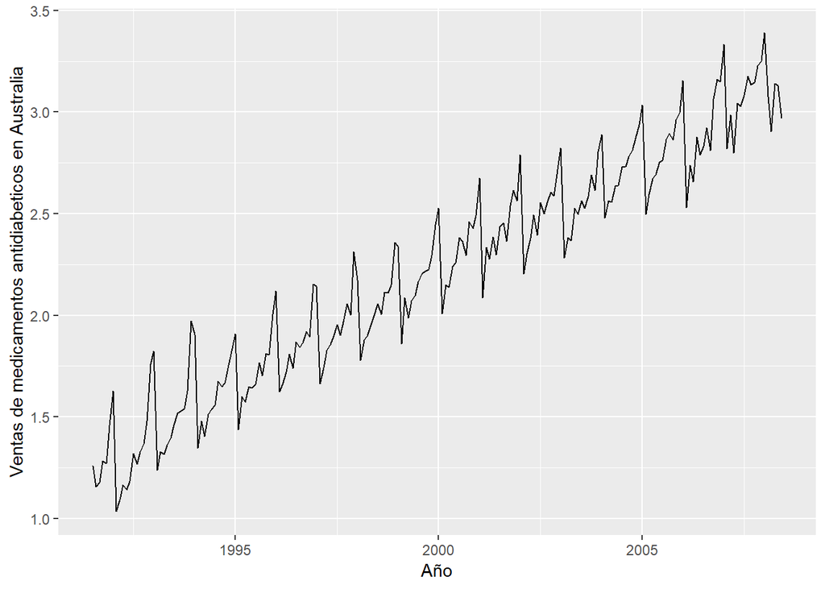

```r
autoplot(log(a10)) +  ylab("Ventas de medicamentos antidiabeticos en Australia") + xlab("Año")
```

Serie quitando el efecto de la tendencia. ¿Es estacionaria?

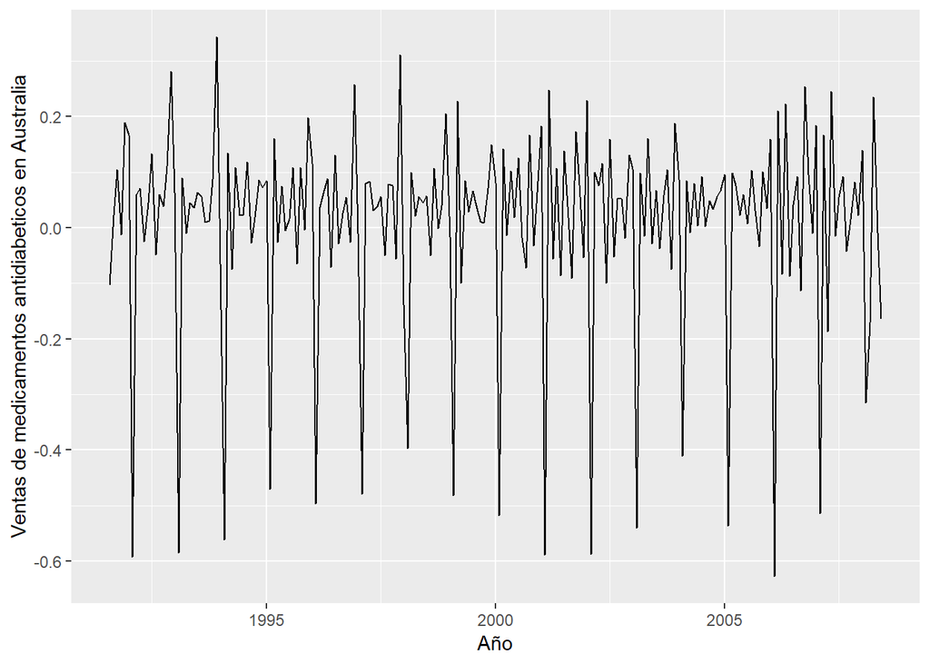

```r
diff.1 <- diff(log(a10))

autoplot(diff.1) +  ylab("Ventas de medicamentos antidiabeticos en Australia") + xlab("Año")
```

Serie quitando el efecto de la tendencia y la estacionalidad. ¿Es estacionaria?

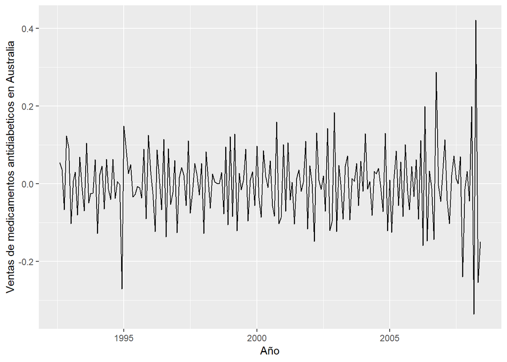

```r
diff.2 <- diff(diff.1,lag=12)

autoplot(diff.2) +  ylab("Ventas de medicamentos antidiabeticos en Australia") + xlab("Año")
```

Visualización de los pasos llevados a cabo para obtener la estacionaridad del proceso

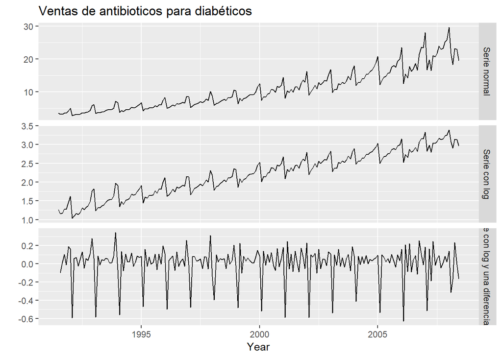

```r
cbind("Serie normal" = a10,
      "Serie con log" = log(a10),
      "Serie con log y una diferenciación" = diff.1) %>%
  autoplot(facets=TRUE) +
  xlab("Year") + ylab("") +
  ggtitle("Ventas de antibioticos para diabéticos")
```

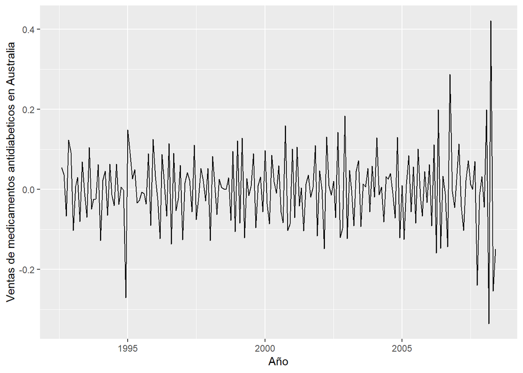

```r
autoplot(diff.2) +  ylab("Ventas de medicamentos antidiabeticos en Australia") + xlab("Año")
```

Cuidado en saltarse o hacer una mala diferenciación

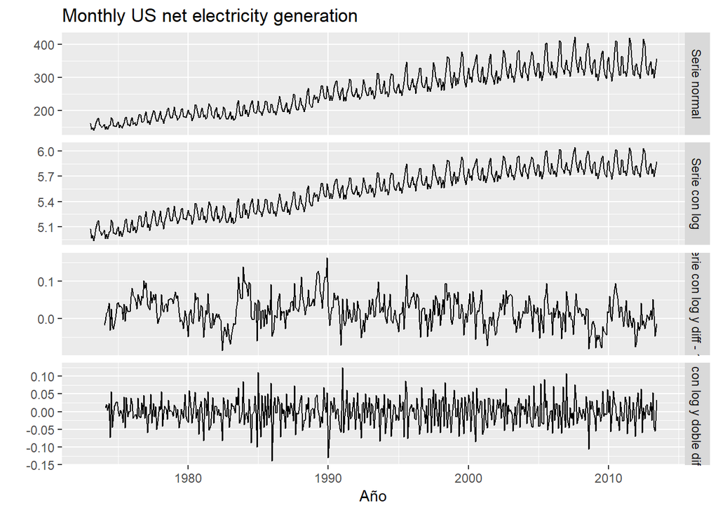

```r
cbind("Serie normal" = usmelec,
      "Serie con log" = log(usmelec),
      "Serie con log y diff - 12" = diff(log(usmelec),12),
      "Serie con log y doble diff - 12" =  diff(diff(log(usmelec),12),1)) %>%
  autoplot(facets=TRUE) +
  xlab("Año") + ylab("") +
  ggtitle("Monthly US net electricity generation")
```

## *Raíces unitaria*

Veamos la búsqueda de las raíces unitaria con los datos sobre acciones de Google

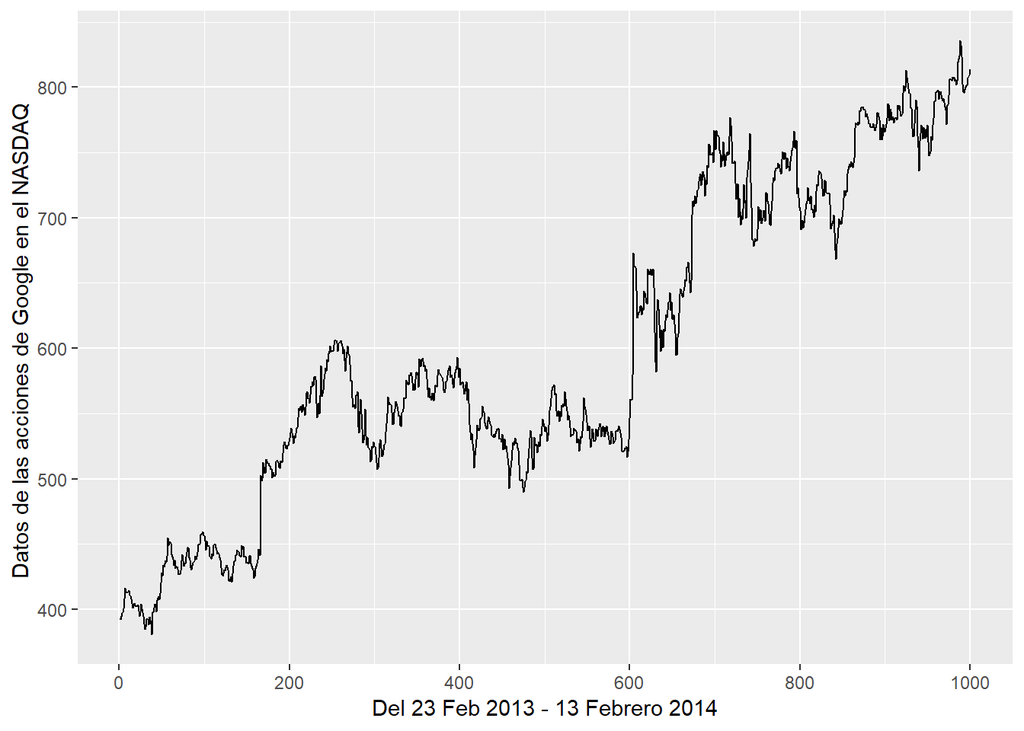

```r
autoplot(goog) +  ylab("Datos de las acciones de Google en el NASDAQ ") +
                xlab("Del 23 Feb 2013 - 13 Febrero 2014")
```

```r
ndiffs(goog)
```

```
## [1] 1
```

Veamos la búsqueda de las raíces unitarias para los datos de la demanda eléctrica

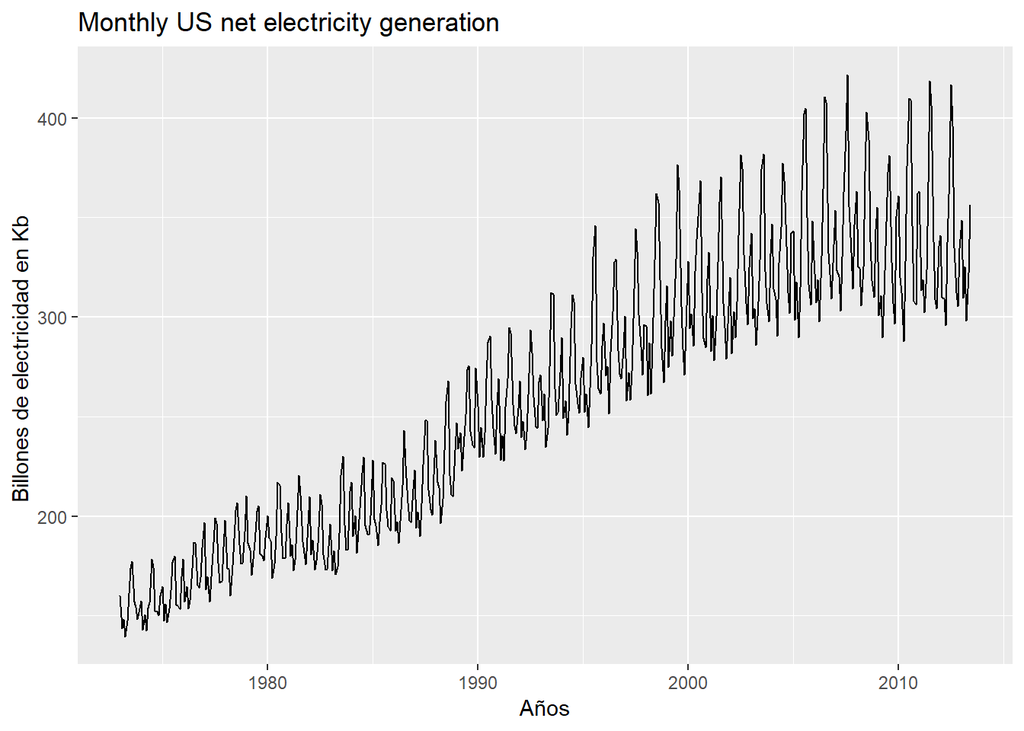

```r
autoplot(usmelec) +  ylab("Billones de electricidad en Kb ") +
                      xlab("Años") +
                      ggtitle("Monthly US net electricity generation")
```

```r
usmelec %>% log() %>% nsdiffs()
```

```
## [1] 1
```

```r
usmelec %>% log() %>% diff(lag=12) %>% ndiffs()
```

```
## [1] 1
```

Veamos la búsqueda de raíces unitarios en los datos de la venta de medicamentos para los diabéticos… estas son un poco extrañas…

```r
autoplot(a10) +  ylab("Ventas de medicamentos antidiabeticos en Australia") + xlab("Año")
```

[output not shown]

```r
a<- a10
b<- log(a10)
c<- diff(log(a10),1)
d<-diff(log(a10),1,12)

a10 %>% log() %>% nsdiffs()
```

```
## [1] 1
```

```r
a %>% log() %>% nsdiffs()
```

```
## [1] 1
```

```r
b %>% log() %>% nsdiffs()
```

```
## [1] 1
```

```r
c %>% log() %>% nsdiffs()
```

```
## [1] 0
```

```r
d %>% log() %>% nsdiffs()
```

```
## [1] 1
```

# Identificación de los procesos ARMA

Simulación de 100 observaciones a partir de un proceso AR(2)

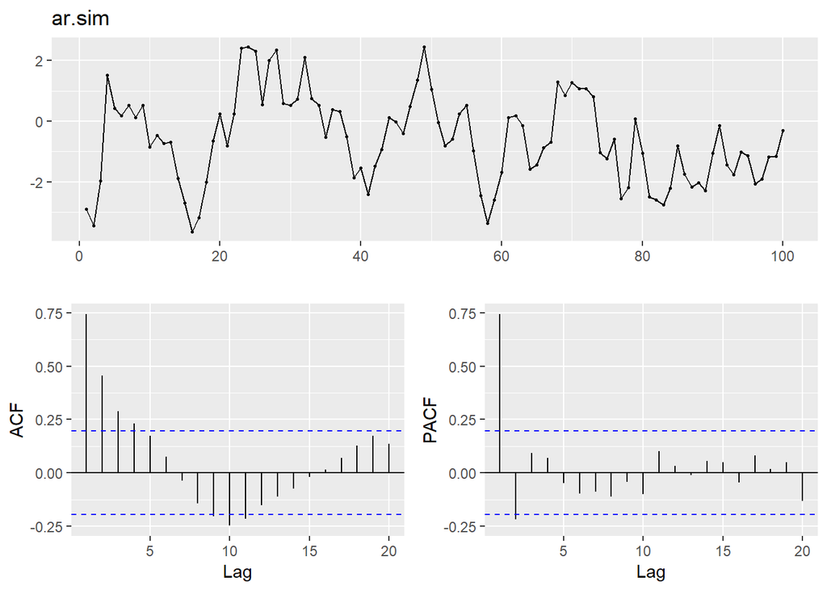

```r
ar.sim<-arima.sim(model=list(ar=c(.9,-.2)),n=100)
ggtsdisplay(ar.sim)
```

Simulación de 100 observaciones a partir de un proceso MA(2)

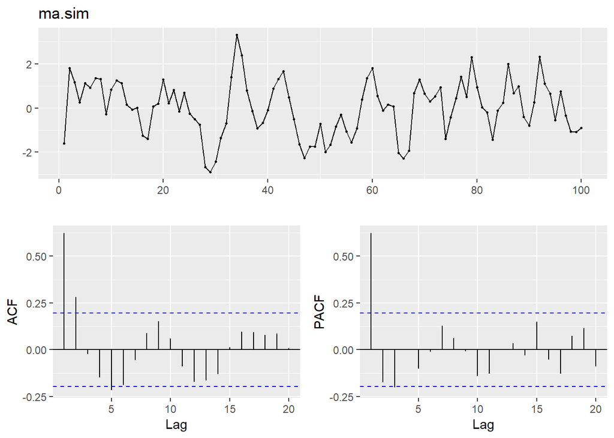

```r
ma.sim<-arima.sim(model=list(ma=c(.8,.4)),n=100)
ggtsdisplay(ma.sim)
```

Simulación de 100 observaciones a partir de un proceso ARMA(2,2)

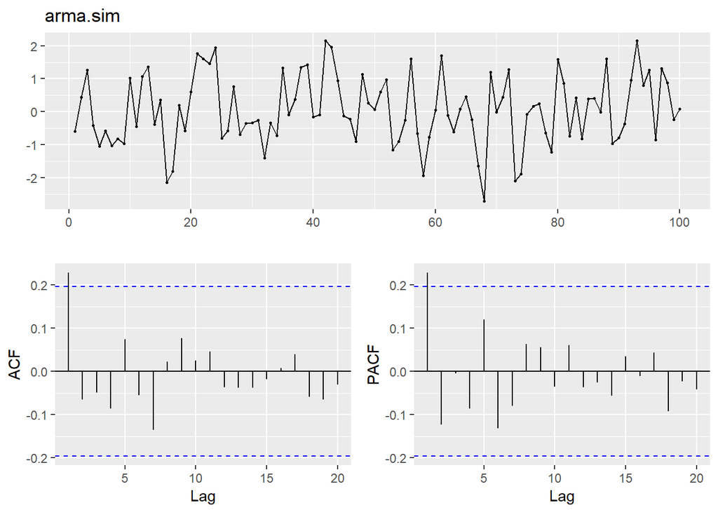

```r
arma.sim<-arima.sim(model=list(ar=c(.9,-.2),ma=c(-.7,.1)),n=100)
ggtsdisplay(arma.sim)
```

Simulemos unos proceso más simples, y veamos que no se debería tomar al dedo los intervalos de confianza

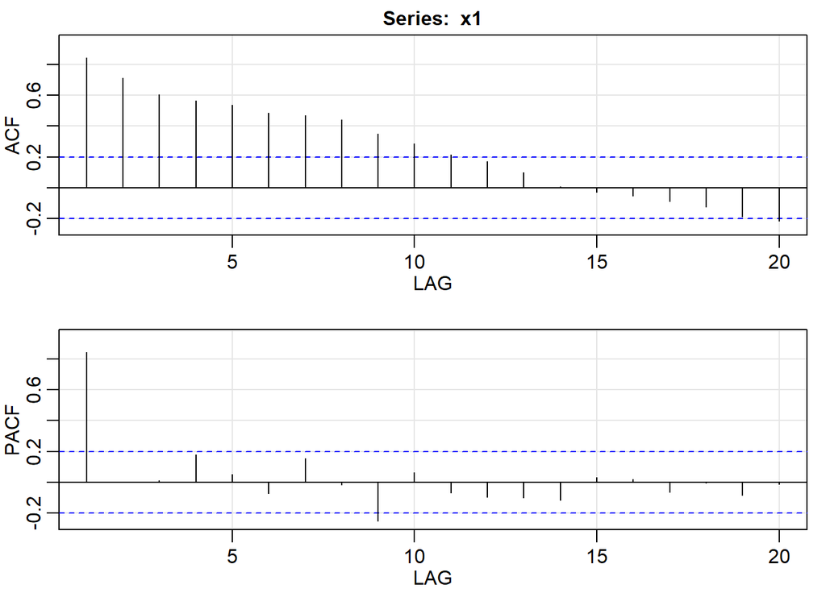

```
##         ACF  PACF
##  [1,]  0.84  0.84
##  [2,]  0.71  0.00
##  [3,]  0.60  0.01
##  [4,]  0.57  0.18
##  [5,]  0.54  0.05
##  [6,]  0.48 -0.07
##  [7,]  0.47  0.15
##  [8,]  0.44 -0.02
##  [9,]  0.35 -0.25
## [10,]  0.29  0.06
## [11,]  0.22 -0.07
## [12,]  0.17 -0.10
## [13,]  0.10 -0.10
## [14,]  0.01 -0.12
## [15,] -0.03  0.03
## [16,] -0.05  0.02
## [17,] -0.09 -0.06
## [18,] -0.13 -0.01
## [19,] -0.19 -0.09
## [20,] -0.22 -0.01
```

```r
x1 <- arima.sim(model = list(order = c(1, 0, 0), ar = .9), n = 100)
acf2(x1)
```

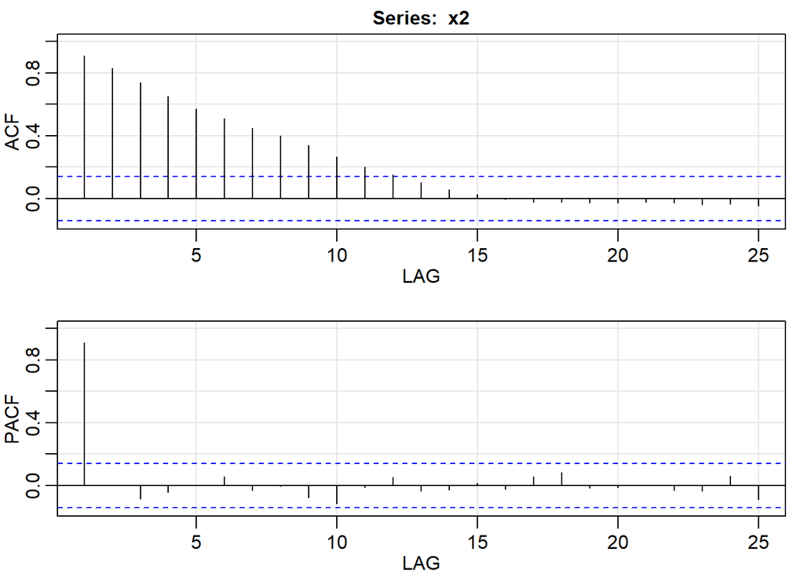

```
##         ACF  PACF
##  [1,]  0.91  0.91
##  [2,]  0.83  0.00
##  [3,]  0.74 -0.08
##  [4,]  0.65 -0.04
##  [5,]  0.57  0.00
##  [6,]  0.51  0.06
##  [7,]  0.45 -0.03
##  [8,]  0.40  0.00
##  [9,]  0.34 -0.08
## [10,]  0.27 -0.11
## [11,]  0.20 -0.01
## [12,]  0.15  0.05
## [13,]  0.10 -0.04
## [14,]  0.06 -0.03
## [15,]  0.02  0.01
## [16,] -0.01 -0.03
## [17,] -0.02  0.06
## [18,] -0.02  0.08
## [19,] -0.03 -0.02
## [20,] -0.03 -0.01
## [21,] -0.02  0.00
## [22,] -0.03 -0.03
## [23,] -0.04 -0.04
## [24,] -0.04  0.06
## [25,] -0.05 -0.09
```

```r
x2 <- arima.sim(model = list(order = c(1, 0, 0), ar = .9), n = 200)
acf2(x2)
```

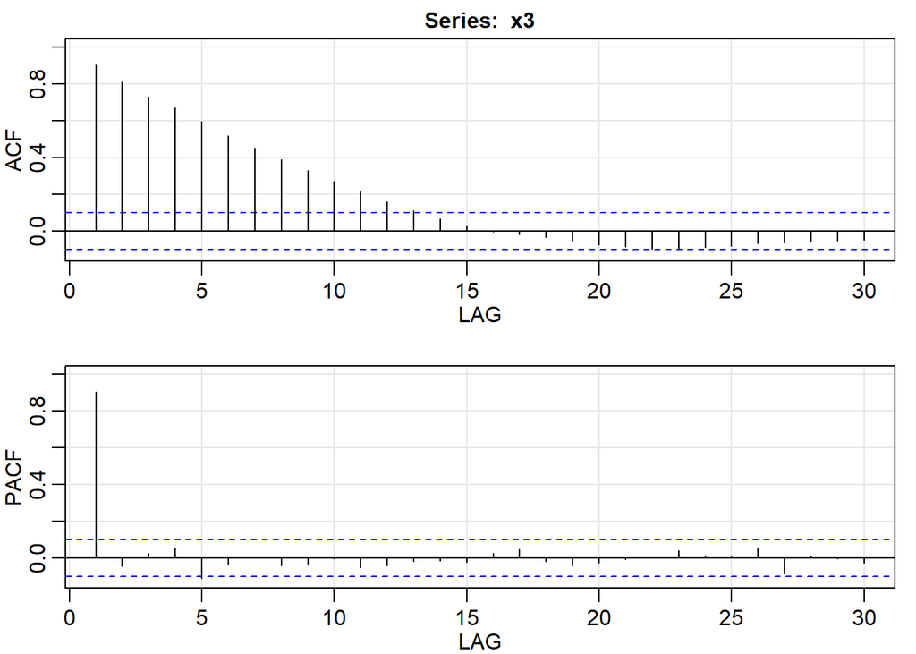

```
##         ACF  PACF
##  [1,]  0.91  0.91
##  [2,]  0.81 -0.04
##  [3,]  0.73  0.03
##  [4,]  0.67  0.06
##  [5,]  0.60 -0.11
##  [6,]  0.52 -0.04
##  [7,]  0.45  0.00
##  [8,]  0.39 -0.04
##  [9,]  0.33 -0.03
## [10,]  0.27  0.00
## [11,]  0.22 -0.05
## [12,]  0.16 -0.04
## [13,]  0.11 -0.02
## [14,]  0.07 -0.01
```

[output cut: 16 more lines]

```r
x3 <- arima.sim(model = list(order = c(1, 0, 0), ar = .9), n = 400)
acf2(x3)
```

# Estimación de los procesos ARMA de los procesos ARMA

## *AR(1)*

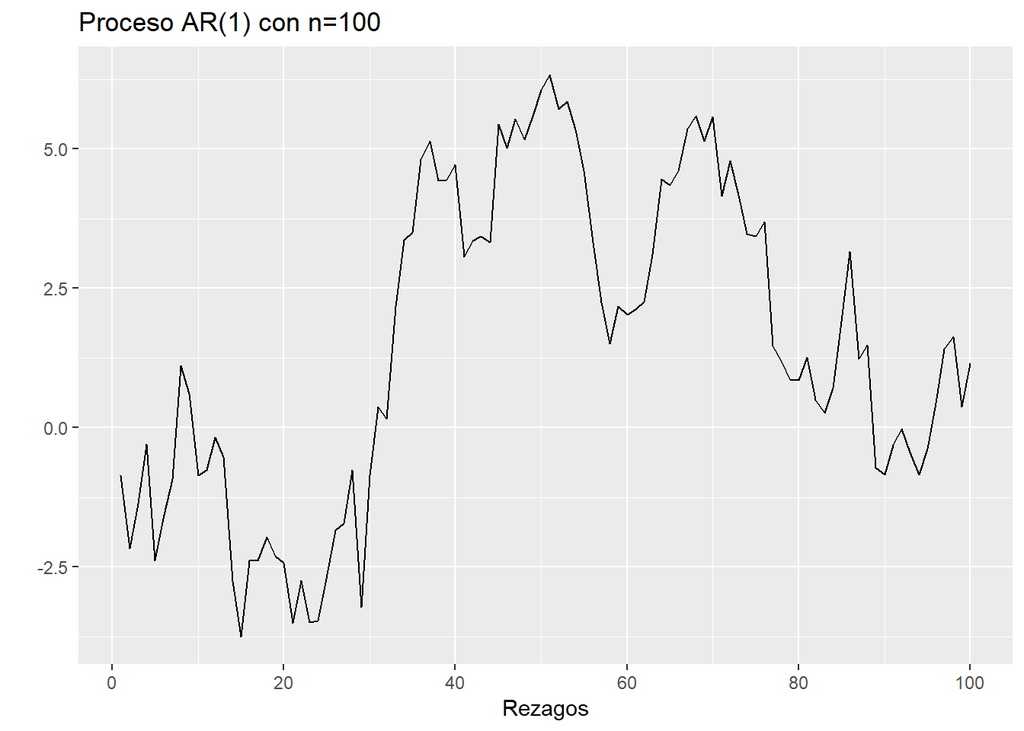

```r
x <- arima.sim(model = list(order = c(1, 0, 0), ar = .9), n = 100)

autoplot(x) +  ylab("") +  xlab("Rezagos") +
            ggtitle("Proceso AR(1) con n=100")
```

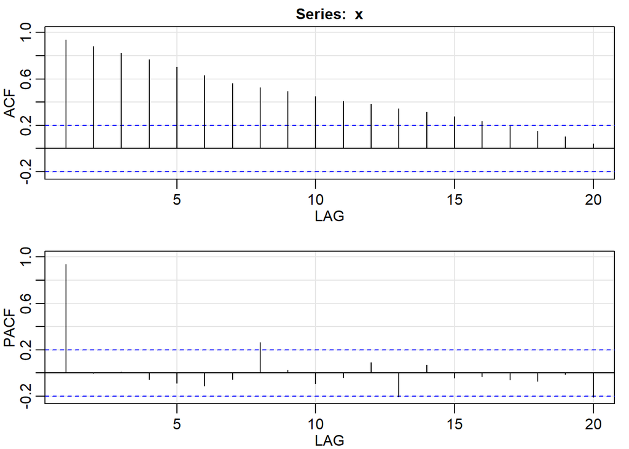

```
##        ACF  PACF
##  [1,] 0.94  0.94
##  [2,] 0.88  0.00
##  [3,] 0.82  0.01
##  [4,] 0.77 -0.06
##  [5,] 0.70 -0.09
##  [6,] 0.63 -0.11
##  [7,] 0.56 -0.05
##  [8,] 0.53  0.26
##  [9,] 0.49  0.03
## [10,] 0.45 -0.09
## [11,] 0.41 -0.04
## [12,] 0.39  0.09
## [13,] 0.35 -0.20
## [14,] 0.32  0.07
## [15,] 0.28 -0.04
## [16,] 0.23 -0.03
## [17,] 0.20 -0.06
## [18,] 0.15 -0.07
## [19,] 0.10 -0.01
## [20,] 0.04 -0.21
```

```r
acf2(x)
```

Ahora estimemos el proceso. ¿Qué podemos decir proceso?

```r
ar.1 <- sarima(x,p=1,d=0,q=0)
```

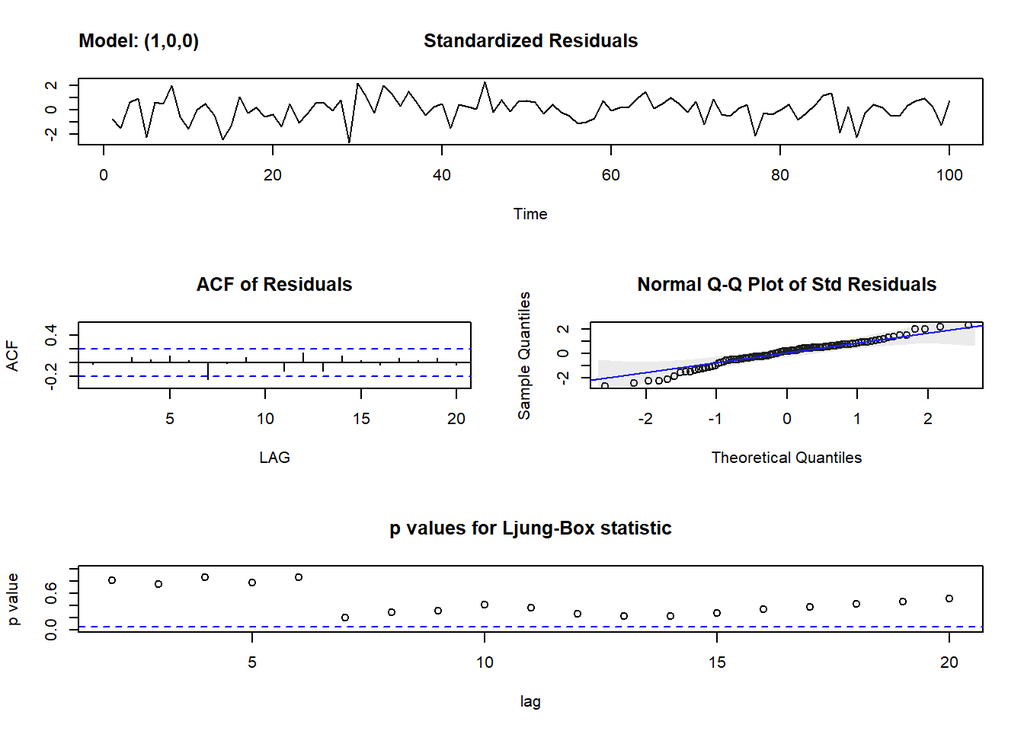

```r
ar.1
```

```
## $fit
##
## Call:
## stats::arima(x = xdata, order = c(p, d, q), seasonal = list(order = c(P, D,
##     Q), period = S), xreg = xmean, include.mean = FALSE, optim.control = list(trace = trc,
##     REPORT = 1, reltol = tol))
##
## Coefficients:
##          ar1   xmean
##       0.9356  1.1857
## s.e.  0.0318  1.3060
##
## sigma^2 estimated as 0.9046:  log likelihood = -137.92,  aic = 281.84
##
## $degrees_of_freedom
## [1] 98
##
## $ttable
##       Estimate     SE t.value p.value
## ar1     0.9356 0.0318 29.4519  0.0000
## xmean   1.1857 1.3060  0.9079  0.3662
##
## $AIC
## [1] 0.939717
##
## $AICc
## [1] 0.962217
##
## $BIC
## [1] -0.008179594
```

```r
ar.1$fit
```

```
##
## Call:
## stats::arima(x = xdata, order = c(p, d, q), seasonal = list(order = c(P, D,
##     Q), period = S), xreg = xmean, include.mean = FALSE, optim.control = list(trace = trc,
##     REPORT = 1, reltol = tol))
##
## Coefficients:
##          ar1   xmean
##       0.9356  1.1857
## s.e.  0.0318  1.3060
##
## sigma^2 estimated as 0.9046:  log likelihood = -137.92,  aic = 281.84
```

```r
ar.1$ttable
```

```
##       Estimate     SE t.value p.value
## ar1     0.9356 0.0318 29.4519  0.0000
## xmean   1.1857 1.3060  0.9079  0.3662
```

## *MA(1)*

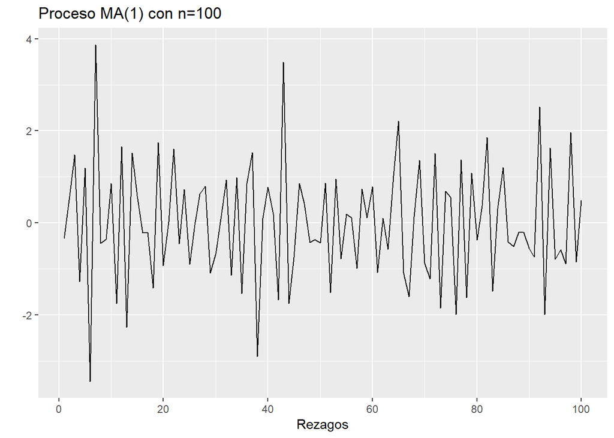

```r
y <- arima.sim(model = list(order = c(0, 0, 1), ma = -.8), n = 100)

autoplot(y) +  ylab("") +  xlab("Rezagos") +
  ggtitle("Proceso MA(1) con n=100")
```

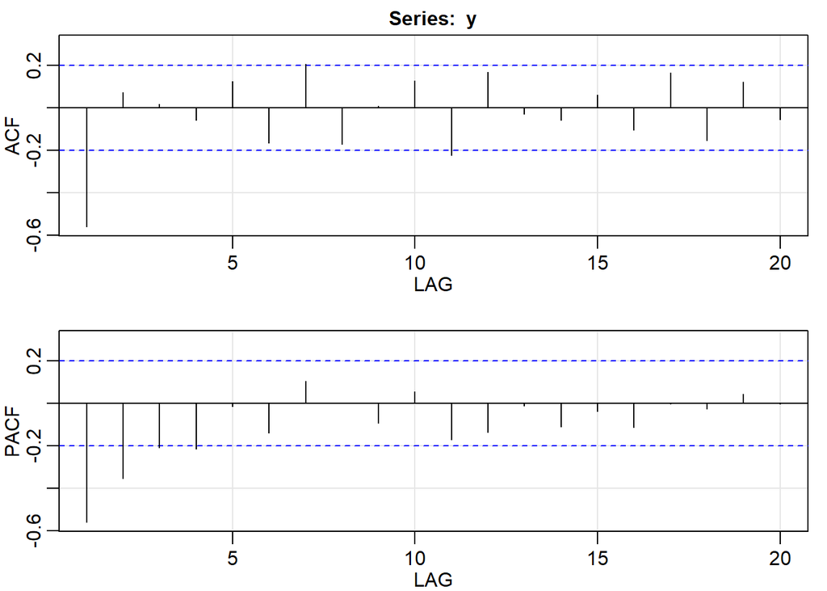

```
##         ACF  PACF
##  [1,] -0.56 -0.56
##  [2,]  0.07 -0.35
##  [3,]  0.02 -0.21
##  [4,] -0.06 -0.22
##  [5,]  0.13 -0.01
##  [6,] -0.16 -0.14
##  [7,]  0.21  0.10
##  [8,] -0.17  0.00
##  [9,]  0.01 -0.09
## [10,]  0.13  0.06
## [11,] -0.22 -0.17
## [12,]  0.17 -0.14
## [13,] -0.03 -0.01
## [14,] -0.06 -0.11
## [15,]  0.06 -0.04
## [16,] -0.10 -0.11
## [17,]  0.17  0.00
## [18,] -0.15 -0.03
## [19,]  0.12  0.04
## [20,] -0.06  0.00
```

```r
acf2(y)
```

Ahora estimemos el proceso. ¿Qué podemos decir proceso?

```r
ma.1 <- sarima(y,p=0,d=0,q=1)
```

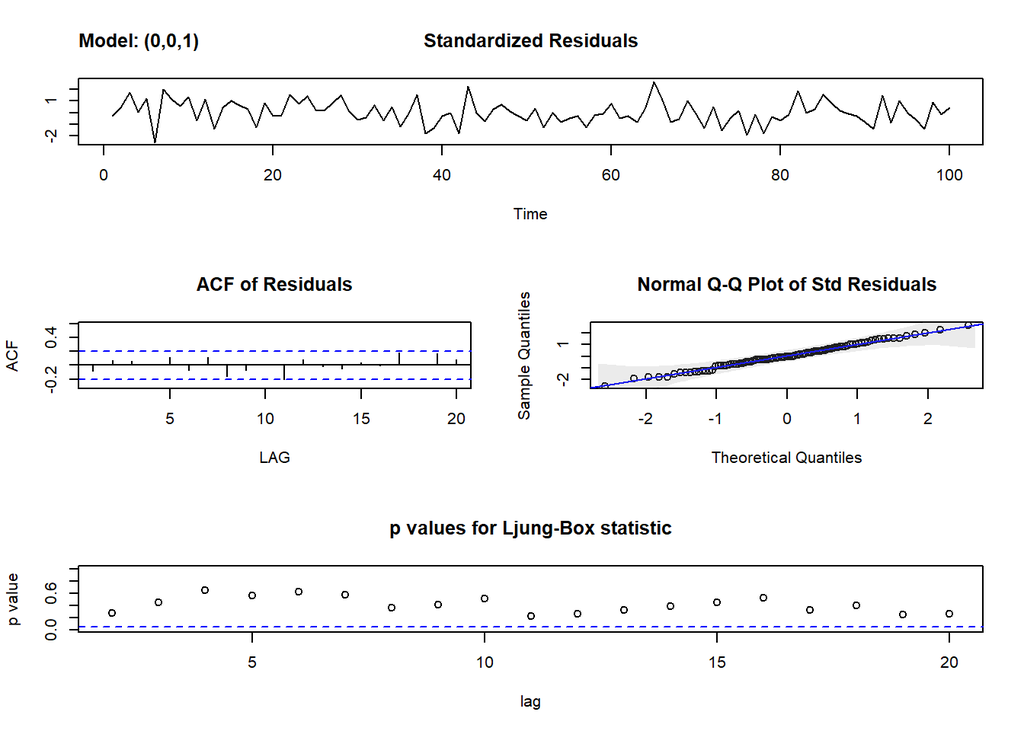

```r
ma.1
```

```
## $fit
##
## Call:
## stats::arima(x = xdata, order = c(p, d, q), seasonal = list(order = c(P, D,
##     Q), period = S), xreg = xmean, include.mean = FALSE, optim.control = list(trace = trc,
##     REPORT = 1, reltol = tol))
##
## Coefficients:
##           ma1    xmean
##       -0.8203  -0.0076
## s.e.   0.0634   0.0180
##
## sigma^2 estimated as 0.9039:  log likelihood = -137.4,  aic = 280.8
##
## $degrees_of_freedom
## [1] 98
##
## $ttable
##       Estimate     SE  t.value p.value
## ma1    -0.8203 0.0634 -12.9382  0.0000
## xmean  -0.0076 0.0180  -0.4225  0.6736
##
## $AIC
## [1] 0.9389393
##
## $AICc
## [1] 0.9614393
##
## $BIC
## [1] -0.008957333
```

```r
ma.1$fit
```

```
##
## Call:
## stats::arima(x = xdata, order = c(p, d, q), seasonal = list(order = c(P, D,
##     Q), period = S), xreg = xmean, include.mean = FALSE, optim.control = list(trace = trc,
##     REPORT = 1, reltol = tol))
##
## Coefficients:
##           ma1    xmean
##       -0.8203  -0.0076
## s.e.   0.0634   0.0180
##
## sigma^2 estimated as 0.9039:  log likelihood = -137.4,  aic = 280.8
```

```r
ma.1$ttable
```

```
##       Estimate     SE  t.value p.value
## ma1    -0.8203 0.0634 -12.9382  0.0000
## xmean  -0.0076 0.0180  -0.4225  0.6736
```